# Attitudes toward Redistribution

TO DO:

? - It cannot be that there is only one wave of Netherlands data, something is wrong with our data compile ? - Two countries still missing GDP, fill in

Nate - get newer measure of socx from OECD, other macro-level variables (GDP in particular)

##### ISSP, Social Inequality, Cumulation (1987, 1992, 1999, 2009 & 2019)

$~$ $~$

#### **Nate Breznau, Lisa Heukamp, Hung H.V. Nguyen, Tom Knuf, Arne Köller, Sören Goldenstein**

#### **University of Bremen**

$~$ $~$

Working paper available here: https://docs.google.com/document/d/1mST25rKYZ5wChRj5WyhxH_65RUa9MNR2OsO5B4-qcwY/edit#

Github repo: https://github.com/hungnguyen167/Social-Status

```r
#df <- readRDS(here::here("data","df.RDS"))
df_na <- readRDS(here::here("data", "df_na.RDS"))
df_macro <- readRDS(here::here("data", "df_macro.RDS"))
```

## Descriptives

### Table 1. Cases by Country-Wave

```r
# Cross-tab years and countries
options(knitr.kable.NA = '')
tab1 <- df_na %>%
  dplyr::group_by(country, wave) %>%
  dplyr::summarize(n=n()) %>%
  spread(wave, n) %>%
  kable(.,
        #col.names = c("Country", "1987", "1992", "1999", "2009", "2019"),
        caption = "Country Sample Size by Wave, ISSP 'Social Inequality (SI)", format.args = list(big.mark = ","))

kable_styling(tab1)
```

Country Sample Size by Wave, ISSP ’Social Inequality (SI)

| country | 1987 | 1992 | 1999 | 2009 | 2019 |
| --- | --- | --- | --- | --- | --- |
| Australia | 1,548 | 2,067 | 1,583 | 1,414 |  |
| Austria | 922 | 975 | 951 | 946 |  |
| Bulgaria |  | 1,056 | 1,048 | 900 |  |
| Canada |  | 953 | 919 |  |  |
| Chile |  |  | 1,427 | 1,475 | 13,360 |
| Croatia |  |  |  |  | 998 |
| Cyprus |  |  | 966 | 912 |  |
| Czechia |  | 648 | 1,766 | 1,180 | 18,590 |
| Denmark |  |  | 1,702 |  | 10,030 |
| Finland |  |  |  |  | 9,140 |
| France |  |  | 1,844 | 2,735 |  |
| Germany | 1,243 | 3,095 | 1,300 | 1,330 | 11,322 |
| Hungary | 2,462 | 1,217 | 1,180 | 1,005 |  |
| Ireland |  |  | 943 |  |  |
| Israel |  |  | 1,196 | 1,171 |  |
| Italy | 1,010 | 990 |  | 1,041 | 11,900 |
| Japan |  |  | 1,174 | 1,180 | 9,429 |
| Latvia |  |  | 1,050 | 1,043 |  |
| Netherlands |  |  |  | 1,227 |  |
| New Zealand |  | 1,170 | 1,038 | 888 | 9,136 |
| Norway |  | 1,458 | 1,213 | 1,364 |  |
| Philippines |  | 1,191 | 1,191 | 1,183 | 4,198 |
| Poland | 1,739 | 1,484 | 1,045 | 1,228 |  |
| Portugal |  |  | 1,123 | 991 |  |
| Russia |  | 1,622 | 1,613 | 1,542 | 1,564 |
| Slovakia |  | 410 | 1,041 | 1,125 |  |
| Slovenia |  | 995 | 975 | 1,042 | 11,303 |
| South Africa |  |  |  |  | 2,652 |
| Spain |  |  | 1,172 | 1,182 |  |
| Sweden |  | 706 | 1,105 | 1,059 |  |
| Switzerland | 918 |  |  | 1,207 | 2,932 |
| Thailand |  |  |  |  | 1,465 |
| United Kingdom | 1,155 | 1,015 | 752 | 921 |  |
| United States | 1,450 | 1,200 | 1,159 | 1,468 |  |

```r
liberal_redist_label <- "Government should take more responsibility to ensure that everyone is provided for [versus] People should take more responsibility to provide for themselves"
liberal_label <- "Private ownership of business and industry should be increased [versus] government ownership..."
confidence_gov_label <- "I am going to name a number of organizations. For each one, could you tell me how much confidence you have in them: is it a great deal of confidence, quite a lot of confidence, not very much confidence or none at all? [the government]"
democratic_label <- "And how democratically is this country being governed today? Again using a scale from 1 to 10, where 1 means that it is “not at all democratic” and 10 means that it is “completely democratic,” what position would you choose?"
```

## Macro-Correlations

```r
# create a variable that captures the percentage of respondents that think income gap is too large but do not agree gov should do something about it


df_macro_corr <- df_macro %>%
  select(-c(iso3c, wave)) %>%
  cor(., use = "pairwise.complete.obs") %>%
  as.data.frame() %>%
  round(.,2)
```

### Puzzling correlation check

The positive correlation of liberal_redist and gov_redist is puzzling. Why would a country have more support for people (versus the govt) taking more responsibility to provide for their own needs and agree that the government should reduce income differences?

To investigate we plot the countries, and the result makes clear that this variable cannot be coded correctly. There is no way that the USA is the most supportive of all countries of the government (versus people themselves) taking responsibility for providing for their needs. Yet the WVS codebook suggets that lower values are more support of government.

This is now fixed in the source load for the WVS so re-creating the plot will not reveal the error.

```r
# df_macro %>%
#   ggplot(aes(y = gov_redist, x = liberal_redist_i)) +
#   geom_label(aes(label = iso3c))
```

### Fig X. Correlation of Redist Variables and Context Vars

After observing the variation in the correlation between inclarge and incdiff by country. We suspect that attitudes toward the role of government are in play. We suspect these come from institutionalized norms.

Theory: individuals have values or follow norms about how much the government should intervene in the socio-economic affairs of individuals, how much the government should protect against social risks and how much the government (society) should share or redistribute based on need.

Hypothesis: In countries where the government does less redistribution or has a weaker welfare state, the correlation between perceptions of the income gap and the idea that the government is responsible for doing something about it will be smaller.

#### Setup Fig

```r
# get all correlations

c_corrs = df_na %>% # have to use equal sign here because it is a function
  subset(!is.na(gov_redist) & !is.na(incdiff_large)) %>% # remove missing cases
  group_by(iso3c, wave) %>% # group by country-wave
  mutate(gov_redist_Z = scale(gov_redist),
         incdiff_large_Z = scale(incdiff_large)) %>%
  do(model = lm(gov_redist_Z ~ incdiff_large_Z, data = .)) #run regression for each country

for (j in 1:96) {
c_corrs$corr[j] <- c_corrs[[3]][[j]][["coefficients"]][2]
}

c_corrs <- select(c_corrs, -model)
# merge with df_macro
df_macro <- left_join(df_macro, c_corrs, by = c("iso3c", "wave"))

# for plotting lines of best fit


# first fill in a few missing gdp
df_macro <- df_macro %>%
  group_by(iso3c) %>%
  mutate(gdp_mean = mean(gdp_pc_10k, na.rm = T),
         gdp_i = ifelse(is.na(gdp_pc_10k), gdp_mean, gdp_pc_10k)) %>%
  ungroup()

# create a variable with all values in one, and then split by high and middle income countries
# need to find a way to adjust for economic growth and unblanaced time points for calculating GDP

df_macro <- df_macro %>%
  mutate(liberal_all = ifelse(!is.na(liberal), liberal, liberal_i),
         liberal_high = ifelse(wave < 2009 & gdp_i > 2.5, liberal_all, NA),
         liberal_high = ifelse(wave >= 2009 & gdp_i > 3.3, liberal_all, liberal_high),
         liberal_high = ifelse(iso3c %in% c("NZL","JPN","DNK","GBR","CHE","AUT", "FIN","DEU"), liberal_all, liberal_high), # selection criteria performs poorly, do rest by hand here
         liberal_low = ifelse(is.na(liberal_high), liberal_all, NA),
         liberal_low = ifelse(iso3c %in% c("HRV","CYP","ITA","SVN","CZE"), NA, liberal_low)) # remove some questionable cases

# for plotting corruption, generate small variation in CPI for years prior to 2015
#make a predicted confidence_gov variable
m_conf <- lm(confidence_gov_i ~ gdp_pc_10k + socx + cpi15_20, data = df_macro)

df_macro$confidence_gov_i_lm <- predict.lm(m_conf, newdata = df_macro)

df_macro <- df_macro %>%
  mutate(cpi15_20 = ifelse(iso3c == "DNK", 90, cpi15_20),
         confidence_gov_i_i = ifelse(is.na(confidence_gov), confidence_gov_i_lm, confidence_gov_i))

# make small disturbances to the cpi using the confidence in gov within-country variance
df_macro <- df_macro %>%
  mutate(cpi15_20_x = (cpi15_20*confidence_gov_i_i)/2)

m_cpi <- lm(cpi15_20_x ~ factor(iso3c) + confidence_gov_i_i, data = df_macro)

df_macro$cpi15_20_i <- predict.lm(m_cpi, newdata = df_macro)

df_macro <- df_macro %>%
  mutate(cpi15_20_i = -1*cpi15_20_i + 100, # reverse scale, higher values more corrupt percept
         cpiZ = scale(cpi15_20_i))

# make high and low corruption perceptions
df_macro <- df_macro %>%
  mutate(cpi_low = ifelse(!is.na(liberal_low), cpiZ, NA),
         cpi_high = ifelse(!is.na(liberal_high), cpiZ, NA))
```

```r
df_na <- df_na %>%
  select(-c(gini_disp, socx))

df_macro <- as.data.frame(df_macro)

df_macro_m <- df_macro %>%
  select(iso3c, wave, cpiZ, liberal_i, gdp_pc_10k, gini_disp, socx, confidence_gov_i_i, cpi15_20_i)

df_na <- df_na %>%
  left_join(df_macro_m, by = c("iso3c", "wave"))
```

#### Plot Liberal Corr

```r
#agg_png(here::here("results","Fig2.png"), res = 144, height = 800, width = 1000)
Fig2.1 <- df_macro %>%
  ggplot() +
  geom_text(aes(y = corr, x = liberal, label = iso3c), color = "black", size = 3) +
  geom_text(aes(y = corr, x = liberal_i, label = iso3c), color = "grey", size = 2) +
  geom_smooth(aes(y = corr, x = liberal_all), method = 'lm', se = F, linetype = "dashed", color = "#B8DE29FF") +
  geom_smooth(aes(y = corr, x = liberal_high), method = 'lm', se = F, color = "#20A387FF") +
  geom_smooth(aes(y = corr, x = liberal_low), method = 'lm', se = F, color = "midnightblue") +
  # geom_segment(aes(x = 6.8, xend = 7.2, y = 0.3, yend = 0.3), linetype = "dashed", color = "#B8DE29FF", size = 1.1) +
  # geom_segment(aes(x = 6.8, xend = 7.2, y = 0.26, yend = 0.26), color = "#20A387FF", size = 1.1) +
  # geom_segment(aes(x = 6.8, xend = 7.2, y = 0.22, yend = 0.22), color = "midnightblue", size = 1.1) +
  # annotate(geom = "text", x = 6.8, y = 0.34, label = "Fitted Lines", hjust = 0) +
  # annotate(geom = "text", x = 7.3, y = 0.3, label = "Pooled", hjust = 0, size = 3) +
  # annotate(geom = "text", x = 7.3, y = 0.26, label = "Higher GDP", hjust = 0, size = 3) +
  # annotate(geom = "text", x = 7.3, y = 0.22, label = "Lower GDP", hjust = 0, size = 3) +
  labs(x = "LIBERAL VALUES\nWorld Values Survey data\ngovernment v. individual responsible for needs",
       y = "CORRELATION within COUNTRY-YEAR\n'Government should redistribute' with\n'Differences in income are too large'",
       caption = " \n \n \n ") +
  theme_classic()
#dev.off()

#knitr::include_graphics(here::here("results","Fig2.png"))
```

#### Plot Corrupt / Corr

```r
#agg_png(here::here("results","Fig3.png"), res = 144, height = 800, width = 1000)
Fig2.2 <- df_macro %>%
  ggplot() +
  geom_text(aes(y = corr, x = cpiZ, label = iso3c), color = "black", size = 3) +
  geom_smooth(aes(y = corr, x = cpiZ), method = 'lm', se = F, linetype = "dashed", color = "#B8DE29FF") +
  geom_smooth(aes(y = corr, x = cpi_high), method = 'lm', se = F, color = "#20A387FF") +
  geom_smooth(aes(y = corr, x = cpi_low), method = 'lm', se = F, color = "midnightblue") +
  geom_segment(aes(x = -2, xend = -1.7, y = 0.3, yend = 0.3), linetype = "dashed", color = "#B8DE29FF", size = 1.1) +
  geom_segment(aes(x = -2, xend = -1.7, y = 0.26, yend = 0.26), color = "#20A387FF", size = 1.1) +
  geom_segment(aes(x = -2, xend = -1.7, y = 0.22, yend = 0.22), color = "midnightblue", size = 1.1) +
  annotate(geom = "text", x = -2, y = 0.34, label = "Fitted Lines", hjust = 0) +
  annotate(geom = "text", x = -1.6, y = 0.3, label = "Pooled", hjust = 0, size = 3) +
  annotate(geom = "text", x = -1.6, y = 0.26, label = "Higher GDP", hjust = 0, size = 3) +
  annotate(geom = "text", x = -1.6, y = 0.22, label = "Lower GDP", hjust = 0, size = 3) +
  labs(x = "CORRUPTION PERCEPTIONS INDEX (CPI)\nTransparency International data\n ",
       y = "",
       caption = " \nY data from International Social Survey Program\ngrey countries in left-panel interpolated with country-means\nwithin-country CPI disturbance generated by authors") +
  theme_classic()
#dev.off()

#knitr::include_graphics(here::here("results","Fig3.png"))
```

### Plot Arranged Figure

```r
agg_png(filename = here::here("results","Fig2.png"), res = 144, width = 1500, height = 800)
ggarrange(Fig2.1, Fig2.2, widths = c(1,1.15))
dev.off()
```

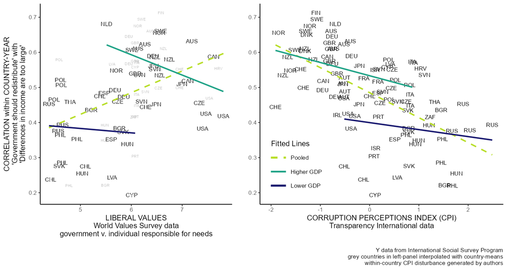

```r
knitr::include_graphics(here::here("results","Fig2.png"))
```

### Moderation Models

This is a cross-level interaction as macro moderator affects the micro association.

```r
m00 <- lmer(gov_redist ~ 1 + incdiff_large + (1 | iso3c) + (1 | wave), data = df_na) # baseline
m01 <- lmer(gov_redist ~ 1 + incdiff_large + cpiZ + (1 | iso3c) + (1 | wave), data = df_na) # with main effects
m02 <- lmer(gov_redist ~ 1 + incdiff_large + cpiZ + (1 | iso3c) + (incdiff_large | wave), data = df_na) # random-slopes
m03 <- lmer(gov_redist ~ 1 + incdiff_large + cpiZ + cpiZ*incdiff_large  + (1 | iso3c) + (1 | wave), data = df_na) # moderation
```

```r
tab_model(m00, m01, m02, m03, show.ci = F, show.aic = T, show.loglik = T, show.icc = T, p.style = "stars")
```

gov_redist

gov_redist

gov_redist

gov_redist

Predictors

Estimates

Estimates

Estimates

Estimates

(Intercept)

1.32 ***

1.32 ***

1.34 ***

1.41 ***

incdiff large

0.60 ***

0.60 ***

0.60 ***

0.58 ***

cpiZ

-0.02

-0.01

0.32 ***

incdiff large * cpiZ

-0.08 ***

Random Effects

σ<sup>2</sup>

0.83

0.83

0.83

0.83

τ<sub>00</sub>

0.05 <sub>iso3c</sub>

0.06 <sub>iso3c</sub>

0.06 <sub>iso3c</sub>

0.06 <sub>iso3c</sub>

0.00 <sub>wave</sub>

0.00 <sub>wave</sub>

0.01 <sub>wave</sub>

0.00 <sub>wave</sub>

τ<sub>11</sub>

0.00 <sub>wave.incdiff_large</sub>

ρ<sub>01</sub>

-0.81 <sub>wave</sub>

ICC

0.06

0.07

0.07

0.07

N

34 <sub>iso3c</sub>

34 <sub>iso3c</sub>

34 <sub>iso3c</sub>

34 <sub>iso3c</sub>

5 <sub>wave</sub>

5 <sub>wave</sub>

5 <sub>wave</sub>

5 <sub>wave</sub>

Observations

217953

217953

217953

217953

Marginal R<sup>2</sup> / Conditional R<sup>2</sup>

0.276 / 0.321

0.273 / 0.322

0.270 / 0.319

0.276 / 0.326

AIC

578853.630

578861.190

578847.192

577614.392

log-Likelihood

-289421.815

-289424.595

-289415.596

-288800.196

- p<0.05 ** p<0.01 *** p<0.001

### Plot Margins

```r
marg_df = as.data.frame(matrix(nrow = 5, ncol = 9))
colnames(marg_df) <- c("cpiZ", "incdiff_large_3", "incdiff_large_4", "b_incd", "b_cpiZ", "b_incXc", "marginal_effect_3", "marginal_effect_4", "margin")

marg_df$cpiZ <- c(-2,-1,0,1,2)
marg_df$incdiff_large_3 <- c(3,3,3,3,3)
marg_df$incdiff_large_4 <- c(4,4,4,4,4)
marg_df$b_incd <- c(0.58,0.58,0.58,0.58,0.58)
marg_df$b_cpiZ <- c(0.32,0.32,0.32,0.32,0.32)
marg_df$b_incXc <- c(-0.08,-0.08,-0.08,-0.08,-0.08)

marg_df <- marg_df %>%
  mutate(marginal_effect_3 = incdiff_large_3*b_incd + cpiZ*b_cpiZ + cpiZ*incdiff_large_3*b_incXc,
         marginal_effect_4 = incdiff_large_4*b_incd + cpiZ*b_cpiZ + cpiZ*incdiff_large_4*b_incXc,
         margin = marginal_effect_4-marginal_effect_3)
```

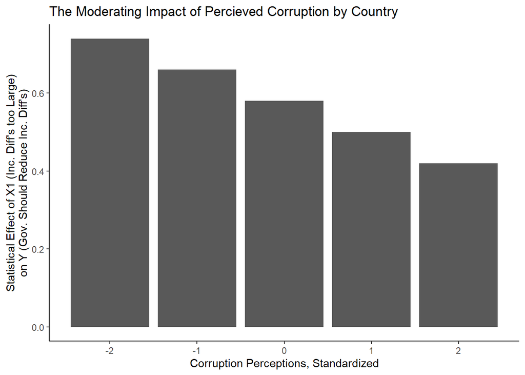

```r
marg_df %>%
  ggplot(aes(x = cpiZ, y = margin)) +
  geom_bar(stat = 'identity') +
  labs(x = "Corruption Perceptions, Standardized",
       y = "Statistical Effect of X1 (Inc. Diff's too Large)\non Y (Gov. Should Reduce Inc. Diff's)",
       title = "The Moderating Impact of Percieved Corruption by Country") +
  theme_classic()
```

Colophon